# Distribution map using survey data

```r
X <- as.data.frame(Xmatrix[,-1])
names(X) <- c(gsub("[:]",".",names(X)))
head(X)
```

```
##    fYear2015 fYear2016 fYear2017 fSurveyNSIBTS HaulDur
## 7          1         0         0             0      30
## 42         0         0         0             0      30
## 43         0         0         0             0      30
## 46         0         0         0             0      30
## 74         1         0         0             0      30
## 75         1         0         0             0      30
```

```r
N <- nrow(cpue_subset)
Stack2 <- inla.stack(
  tag  = "Fit",
  data = list(y = cpue_subset$NoPerHaul),
  A    = list(1,1, A2),
  effects = list(
    Intercept = rep(1, N),
    X = as.data.frame(X), # Covariates
    w.st))                # Spatial-temp field
```

```r
fsp <- parse(text=c("y ~ -1 + Intercept + ",
                    paste(c(names(X)," f(w, model = spde, group =       w.group, control.group = list(model = 'ar1'))"),collapse =" + ")))
```

```r
#INLA:::inla.dynload.workaround()
I2nb <- inla(eval(fsp), family = "nbinomial",
           data=inla.stack.data(Stack2),
           control.compute = list(dic = TRUE, waic = TRUE),
           control.predictor = list(A = inla.stack.A(Stack2)))
```

```r
summary(I2nb)
```

```
##
## Call:
## c("inla(formula = eval(fsp), family = \"nbinomial\", data = inla.stack.data(Stack2), ",  "    control.compute = list(dic = TRUE, waic = TRUE), control.predictor = list(A = inla.stack.A(Stack2)))" )
##
## Time used:
##  Pre-processing    Running inla Post-processing           Total
##           1.801         974.122           5.138         981.061
##
## Fixed effects:
##                  mean      sd 0.025quant 0.5quant 0.975quant    mode kld
## Intercept     -4.7267 31.5326   -66.6776  -4.7206    57.1324 -4.7052   0
## fYear2015      0.0030  0.0634    -0.1214   0.0030     0.1273  0.0030   0
## fYear2016     -0.0127  0.0636    -0.1375  -0.0127     0.1122 -0.0127   0
## fYear2017     -0.1098  0.0971    -0.3017  -0.1094     0.0798 -0.1086   0
## fSurveyNSIBTS -0.9560  0.0599    -1.0738  -0.9559    -0.8386 -0.9558   0
## HaulDur        0.0254  0.0057     0.0142   0.0254     0.0367  0.0253   0
##
## Random effects:
## Name   Model
##  w   SPDE2 model
##
## Model hyperparameters:
##                                                           mean     sd
## size for the nbinomial observations (1/overdispersion)  1.8231 0.0028
## Theta1 for w                                            2.5910 0.0017
## Theta2 for w                                           -7.7878 0.0019
## GroupRho for w                                          0.5278 0.0011
##                                                        0.025quant 0.5quant
## size for the nbinomial observations (1/overdispersion)     1.8181    1.823
## Theta1 for w                                               2.5876    2.591
## Theta2 for w                                              -7.7910   -7.788
## GroupRho for w                                             0.5253    0.528
##                                                        0.975quant    mode
## size for the nbinomial observations (1/overdispersion)     1.8289  1.8223
## Theta1 for w                                               2.5944  2.5911
## Theta2 for w                                              -7.7837 -7.7887
## GroupRho for w                                             0.5296  0.5285
##
## Expected number of effective parameters(std dev): 186.78(0.1773)
## Number of equivalent replicates : 57.38
##
## Watanabe-Akaike information criterion (WAIC) ...: 189973.51
## Effective number of parameters .................: 90661.92
##
## Marginal log-Likelihood:  -9391.62
## Posterior marginals for linear predictor and fitted values computed
```

The “UTMmap” object for creating the maps we still have.

```r
w <- I2nb$summary.random$w$mean
# length of w is mesh$n * NGroups

wproj <- inla.mesh.projector(mesh2a, xlim = range(Loc[,1]), ylim = range(Loc[,2]))

grid <- expand.grid(IDX=1:NGroups, x = wproj$x, y = wproj$y,zm=NA)

for (i in 1: NGroups){
    w.pm100100 <- inla.mesh.project(wproj,w[w.st$w.group==i])
    grid[grid$IDX==i,]$zm <- as.vector(w.pm100100)  }
```

Next we print the grid, which is now estimated at each knot.

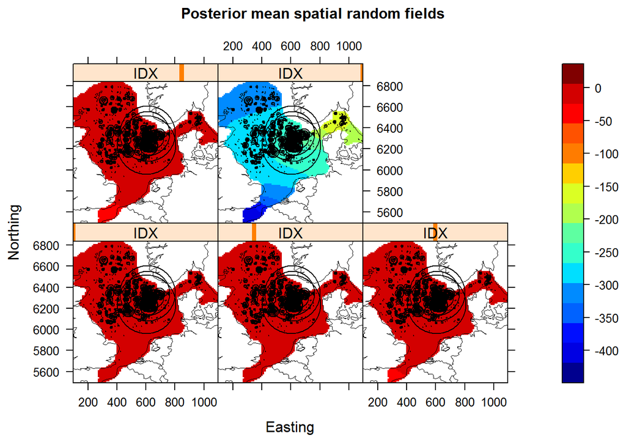

```r
print(levelplot(zm ~ x * y |IDX,
          data = grid,
          scales = list(draw = TRUE),
          xlab = list("Easting", cex = 1),
          ylab = list("Northing", cex = 1),
          main = list("Posterior mean spatial random fields", cex = 1),
          col.regions=tim.colors(25, alpha = 1),
          panel=function(x, y, z, subscripts,...){
            panel.levelplot(x, y, z, subscripts,...)
            grid.points(x = cpue_subset$Xkm,
                        y = cpue_subset$Ykm,
                        pch = 1,
                        size = unit(cpue_subset$NoPerHaul/10, "char"))
          }) +  xyplot(ym~ xm, UTMmapFinal, type='l', lty=1, lwd=0.5, col='black'))
```

## Including length in the survey catchability

```r
# 5. Make a stack.
Xmatrix <- model.matrix(~  fYear + fSurvey + HaulDur,  data = cpue_subset)

head(Xmatrix)
```

```
##    (Intercept) fYear2015 fYear2016 fYear2017 fSurveyNSIBTS HaulDur
## 7            1         1         0         0             0      30
## 42           1         0         0         0             0      30
## 43           1         0         0         0             0      30
## 46           1         0         0         0             0      30
## 74           1         1         0         0             0      30
## 75           1         1         0         0             0      30
```

```r
X <- as.data.frame(Xmatrix[,-1])
names(X) <- c(gsub("[:]",".",names(X)))
head(X)
```

```
##    fYear2015 fYear2016 fYear2017 fSurveyNSIBTS HaulDur
## 7          1         0         0             0      30
## 42         0         0         0             0      30
## 43         0         0         0             0      30
## 46         0         0         0             0      30
## 74         1         0         0             0      30
## 75         1         0         0             0      30
```

```r
N <- nrow(cpue_subset)
Stack3 <- inla.stack(
  tag  = "Fit",
  data = list(y = cpue_subset$NoPerHaul),
  A    = list(1,1, A2),
  effects = list(
    Intercept = rep(1, N),
    X = as.data.frame(X), # Covariates
    w.st))                # Spatial-temp field
```

```r
fsp <- parse(text=c("y ~ -1 + Intercept + ",
                    paste(c(names(X)," f(w, model = spde, group =       w.group, control.group = list(model = 'ar1'))", "f(LngtClass, group=fSurvey,'rw2')",collapse =" + ")))
```

```r
#INLA:::inla.dynload.workaround()
I3nb <- inla(eval(fsp), family = "nbinomial",
           data=inla.stack.data(Stack3),
           control.compute = list(dic = TRUE, waic = TRUE),
           control.predictor = list(A = inla.stack.A(Stack3)))
```

```r
summary(I3nb)
```

[output not shown]

## Using swept area estimates

Reread IBTS data

```r
cpue_IBTS <- read.csv(file.path(path,"CPUE per length per haul_2017-07-12 11_18_36.csv"), stringsAsFactors = F)
cpue_IBTS$NoPerHaul <- round(cpue_IBTS$CPUE_number_per_hour*(cpue_IBTS$HaulDur/60))
cpue_IBTS <- cpue_IBTS[!(names(cpue_IBTS) %in% c("DateofCalculation", "Area", "SubArea", "DayNight","Species","Sex","DateTime","CPUE_number_per_hour"))]

cpue_IBTS$uniqueHaul <-   paste(cpue_IBTS$Year, cpue_IBTS$Survey, cpue_IBTS$Quarter, cpue_IBTS$Ship, cpue_IBTS$HaulNo, cpue_IBTS$ShootLat, cpue_IBTS$ShootLon, sep="_")
```

File contains HH records in exchange files for IBTS. NA for door spread and distance are coded as -9, so make NAs of those.

```r
HH_IBTS <- read.csv(file.path(path,"Exchange Data_2017-07-14 09_26_25.csv"), stringsAsFactors = F)

HH_IBTS$uniqueHaul <-  paste(HH_IBTS$Year, HH_IBTS$Survey, HH_IBTS$Quarter, HH_IBTS$Ship, HH_IBTS$HaulNo, HH_IBTS$ShootLat, HH_IBTS$ShootLon, sep="_")

HH_IBTS[HH_IBTS$DoorSpread == -9,]$DoorSpread <- NA
HH_IBTS[HH_IBTS$Distance == -9,]$Distance <- NA
HH_IBTS[HH_IBTS$Netopening == -9,]$Netopening <- NA

HH_IBTS$surface <- HH_IBTS$Distance * HH_IBTS$Netopening
```

Select only relevant variables, and remove all hauls longer than 90 minutes

```r
HH_IBTS <- HH_IBTS[names(HH_IBTS) %in% c("uniqueHaul", "surface", "HaulDur","Doorspread","Ditance","Netopening","Warplngt")]
HH_IBTS <- HH_IBTS[HH_IBTS$HaulDur<=90,]
```

Plot surface against duration hoping to find corr

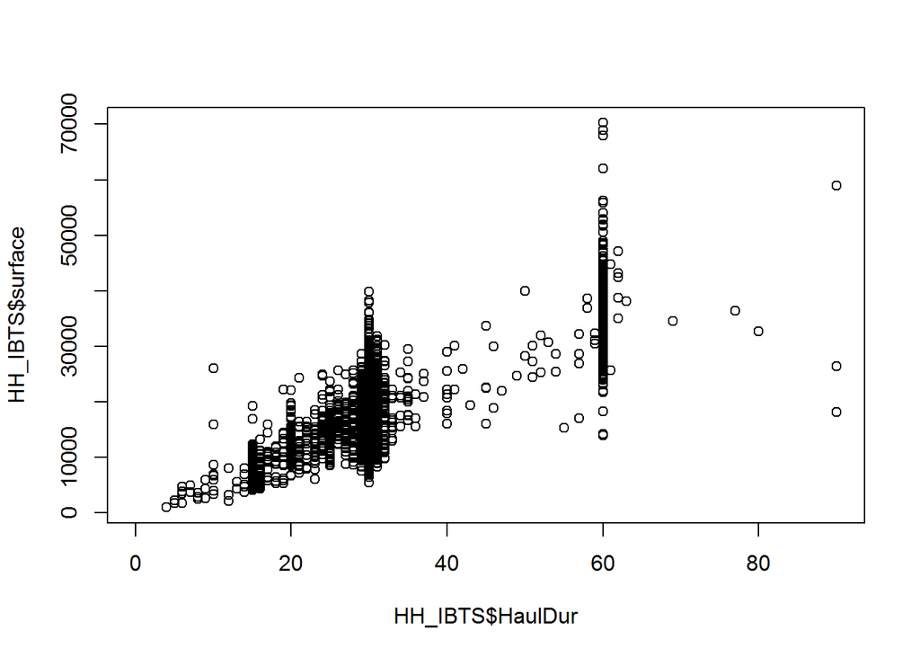

```r
plot(x=HH_IBTS$HaulDur,y=HH_IBTS$surface)
```

```r
summary(lm(surface~HaulDur, data=HH_IBTS))
```

```
##
## Call:
## lm(formula = surface ~ HaulDur, data = HH_IBTS)
##
## Residuals:
##    Min     1Q Median     3Q    Max
## -34931  -2186   -134   1979  34770
##
## Coefficients:
##             Estimate Std. Error t value Pr(>|t|)
## (Intercept)  229.092    139.597   1.641    0.101
## HaulDur      587.464      4.482 131.067   <2e-16 ***
## ---
## Signif. codes:  0 '***' 0.001 '**' 0.01 '*' 0.05 '.' 0.1 ' ' 1
##
## Residual standard error: 3531 on 14777 degrees of freedom
##   (12906 observations deleted due to missingness)
## Multiple R-squared:  0.5376, Adjusted R-squared:  0.5375
## F-statistic: 1.718e+04 on 1 and 14777 DF,  p-value: < 2.2e-16
```

Merge haulinfo to full cpue set

```r
cpue_IBTS <- merge(cpue_IBTS, HH_IBTS, all.x=T, all.y=F)
```

```r
cpue_BTS  <- read.csv(file.path(path,"CPUE per length per Hour and Swept Area_2017-07-12 11_29_36.csv"), stringsAsFactors = F)
cpue_BTS <- cpue_BTS[!(names(cpue_BTS) %in% c("Country","DoorType","HaulLat","HaulLong","StatRec","DataType","Rigging","Tickler","Warplngt","TowDir","WindDir","WindSpeed","SwellDir","SwellHeight","StNo","Month","Day","TimeShot","Stratum","ICESArea","DateofCalculation", "Area", "SubArea", "DayNight","Species", "Sex","SpecVal","SubFactor","GearExp","SweepLngt","Netopening","BycSpecRecCode","StdSpecRecCode","HaulVal","CPUE_number_per_hour","CPUE_number_per_km2","SweptArea_km2","DistanceDerived", "HLNoAtLngt"))]
surface
```

[output not shown]

```r
cpue_BTS[is.na(cpue_BTS$LngtClass),]$NoPerHaul <- 0
cpue_BTS[is.na(cpue_BTS$LngtClass),]$LngtClass <- 0

cpue_BTS$surface <- cpue_BTS$Distance * cpue_BTS$BeamWidth

cpue_BTS$uniqueHaul <-   paste(cpue_BTS$Year, cpue_BTS$Survey, cpue_BTS$Quarter, cpue_BTS$Ship, cpue_BTS$HaulNo, cpue_BTS$ShootLat, cpue_BTS$ShootLon, sep="_")
```

Next we combine the two sets into one.

```r
cols <- intersect(colnames(cpue_BTS), colnames(cpue_IBTS))
cpue <- rbind(cpue_BTS[,cols],cpue_IBTS[,cols])
```

Now that the IBTS and BTS data sets are combined we want to make a set where we have counts for all hauls and all lenghts. This means first making an dentifier for each unique haul (based on the information we have for all the hauls). This identifier is used to make a “trawllist” where all the information for the hauls is stored.

Once the trawllist is make we use epand.grid() to make a combination of all hauls and lenght classes. This set is merged with our original data set.

```r
trawllist <- cpue[!duplicated(cpue$uniqueHaul),!names( cpue) %in% c("Species","AphiaID","NoPerHaul","Sex", "LngtClass")]

#expand grid
haulsLengths <- expand.grid(uniqueHaul=unique(cpue$uniqueHaul),LngtClass=unique(cpue$LngtClass), stringsAsFactors = F)
full_cpue <- merge(haulsLengths,cpue[names(cpue) %in% c("uniqueHaul", "LngtClass","NoPerHaul")], all.x=T)
rm(haulsLengths)
head(full_cpue)
```

```
##                          uniqueHaul LngtClass NoPerHaul
## 1 1966_NS-IBTS_1_AND_1_54.2333_7.45         0         0
## 2 1966_NS-IBTS_1_AND_1_54.2333_7.45        10        NA
## 3 1966_NS-IBTS_1_AND_1_54.2333_7.45        20        NA
## 4 1966_NS-IBTS_1_AND_1_54.2333_7.45        30        NA
## 5 1966_NS-IBTS_1_AND_1_54.2333_7.45        50        NA
## 6 1966_NS-IBTS_1_AND_1_54.2333_7.45        60        NA
```

After we merged all possible combinations with the data we now have NAs for those lengts and hauls where the catch is zero, and so we set those to zero. This data is subsequently merged to the trawllist so that we now have all information together.

```r
full_cpue[is.na(full_cpue$NoPerHaul),]$NoPerHaul <- 0
full_cpue  <- merge(full_cpue,trawllist, all.x=T)
```

The records that have lenghts equal to zero (that indicated zero hauls in our original set ) now need to be removed because we have all the information we need (these hauls now have zero catch for the full length range observed in the survey).

In addition, there are some observations that are highly unlikely: For instance there is a single observation of an individual of 100 cm (in 1977). This is suspicious, and we remove it from the data.

```r
#now remove zero lengths
full_cpue <- full_cpue[full_cpue$LngtClass> 0,]

full_cpue <- full_cpue[full_cpue$LngtClass< 990,]
```

For our spatial correlation we will need an isomorphic coordinate system. Therefore we transform the latitudes and longitudes to UTM coordinates. these UTM coordinates are given in meters, so we divide them by 1000 to get kilometers.

```r
UTM <- project(cbind(full_cpue$ShootLong, full_cpue$ShootLat), "+proj=utm +zone=31U ellps=WGS84")

full_cpue$Xkm <- UTM[,1]/1000
full_cpue$Ykm <- UTM[,2]/1000
```

The INLA code does not like special characters in some of the variable names, like the hyphen in “NS-IBTS”. Therefore we rename the survey to NSIBTS.

```r
#recode survey names so that there are no special characters
full_cpue[full_cpue$Survey=="NS-IBTS",]$Survey <- "NSIBTS"
```

```r
# make selection of  fullset.
cpue_subset <- full_cpue[full_cpue$Year >= 2013,]
```

```r
# Simulate from model I1nb

# Simulation study spatial Negbin model.
# First set random seed and the number of simulations
set.seed(12345)
NSim <- 1000

# Carry out the simulation
Sim <- inla.posterior.sample(n = NSim, result = I1nb)

# Now we have 1000 simulated betas and also 1000 spatial fields w
# Use these to calculate 1000 times the expected values mu,
# and simulate count data from these using rpois

# X matrix
#Xm      <- model.matrix(~BreedingD.std + Rain.std, data = cpue_subset)
Xm <- model.matrix(~  fYear + fSurvey +  HaulDur  ,  data = cpue_subset)

# Create space to store the information
N    <- nrow(cpue_subset)
Ysim <- matrix(nrow = N, ncol = NSim)
mu.i <- matrix(nrow = N, ncol = NSim)
Xm   <- as.matrix(Xm)
Am   <- as.matrix(A3)

# We are calculating a Fixed part (X * beta) and also the random part (A * w)
for (i in 1: NSim){
  Betas    <- Sim[[i]]$latent[c(987, 988, 989)]
  wk       <- Sim[[i]]$latent[416:986]
  eta      <- Xm %*% Betas + Am %*% wk
  mu.i[,i] <- exp(eta)
  Ysim[,i] <- rpois(n = nrow(OCW), lambda = mu.i[,i])
}

# Now we have 1,000 simulated count data sets from the model

# And plot the results of the simulation study
Z <- matrix(nrow = max(Ysim)+1, ncol = NSim)
for (i in 1: NSim){
    zi <- table(Ysim[,i])
    I <- as.numeric(names(zi)) + 1
    Z[I,i] <- zi
}


#############################################
```